# Use cases

In this notebook, we describe different use cases for applying stochastic service composition.

```
# Python imports, put at the top for simplicity
from mdp_dp_rl.algorithms.dp.dp_analytic import DPAnalytic
from docs.notebooks.utils import render_service, render_target, render_composition_mdp, print_policy_data, print_value_function, print_q_value_function
from stochastic_service_composition.composition import composition_mdp
from stochastic_service_composition.services import build_service_from_transitions
from stochastic_service_composition.target import build_target_from_transitions
```

## Simple service composition: Website

This simple example, showed in

[De Giacomo, G., Mecella, M., & Patrizi, F. (2014). Automated service composition based on behaviors: The roman model. In Web services foundations (pp. 189-214). Springer, New York, NY.](http://www.diag.uniroma1.it/degiacom/papers/2014/WSF14.pdf)

consists of a simple website in which the user wants to login, choose the country, stock, and logout (c). We then have the login service (a) and the form service (b). The orchestrator (d) has to assign the action to the right service. This case is quite trivial as there is no competition among services since they always support different actions. The reward, in our case, is given whenever the user is able to complete the entire sequence of actions, right after the logout

[figure not shown]

Let us define the service community:

```
login_service = build_service_from_transitions(
    {
        "s0": {"login": "s1"},
        "s1": {"logout": "s0"}
    },
    "s0",
    {"s0"}
)

form_service = build_service_from_transitions(
    {
        "s0": {"country": "s1"},
        "s1": {"currency": "s0", "stock": "s0"}
    },
    "s0",
    {"s0"}
)
```

The login service:

```
render_service(login_service)
```

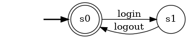

The form service:

```
render_service(form_service)
```

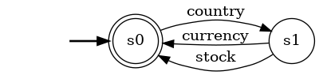

Now we define the target service:

```
target = build_target_from_transitions(
    {
        "s0": {"login": ("s1", 1.0, 0.0)},
        "s1": {"country": ("s2", 1.0, 0.0)},
        "s2": {"stock": ("s3", 1.0, 0.0)},
        "s3": {"logout": ("s0", 1.0, 1.0)},
    },
    "s0",
    {"s0"}
)
render_target(target)
```

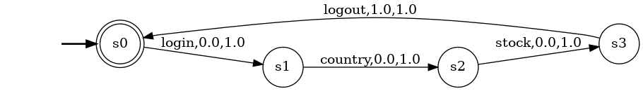

The product MDP is:

```
mdp = composition_mdp(target, login_service, form_service)
render_composition_mdp(mdp)
```

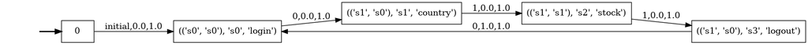

The optimal policy is the only one allowed

```
opn = DPAnalytic(mdp, 1e-4)
opt_policy = opn.get_optimal_policy_vi()
value_function = opn.get_value_func_dict(opt_policy)
q_value_function = opn.get_act_value_func_dict(opt_policy)

# remove '0' state to sort output
opt_policy.policy_data.pop(0, None)
value_function.pop(0, None)
q_value_function.pop(0, None)

print_policy_data(opt_policy)
print()
print_value_function(value_function)
print()
print_q_value_function(q_value_function)
```

```
Policy:
State=(('s0', 's0'), 's0', 'login'),    Action=0
State=(('s1', 's0'), 's1', 'country'),  Action=1
State=(('s1', 's0'), 's3', 'logout'),   Action=0
State=(('s1', 's1'), 's2', 'stock'),    Action=1

Value function:
State=(('s0', 's0'), 's0', 'login'),    value=2.119802268101193
State=(('s1', 's0'), 's1', 'country'),  value=2.3553358534457702
State=(('s1', 's0'), 's3', 'logout'),   value=2.907822041291074
State=(('s1', 's1'), 's2', 'stock'),    value=2.6170398371619665

Q-value function:
State=(('s0', 's0'), 's0', 'login'):
    Action=0,   Value=2.119802268101193

State=(('s1', 's0'), 's1', 'country'):
    Action=1,   Value=2.35533585344577

State=(('s1', 's0'), 's3', 'logout'):
    Action=0,   Value=2.907822041291074

State=(('s1', 's1'), 's2', 'stock'):
    Action=1,   Value=2.6170398371619665
```

That is, as expected, `login` and `logout` are assigned to service `0` and `country` and `stock` to service `1`.

## A variant of the website service

Here we consider a variant in which the services can erroneously report that they can provide a service, but that leads to a dead-end. An exact solution is still possible, and the solution of the composition MDP will lead to the right orchestration.

Let's define the same services, but with additional actions:

```
login_service = build_service_from_transitions(
    {
        "s0": {
            "login": "s1"
        },
        "s1": {
            "logout": "s0",
            "country": "error",
            "currency": "error",
            "stock": "error"
        },
        "error": {}
    },
    "s0",
    {"s0"}
)

form_service = build_service_from_transitions(
    {
        "s0": {"login": "error", "logout": "error", "country": "s1"},
        "s1": {"currency": "s0", "stock": "s0"},
        "error": {}
    },
    "s0",
    {"s0"}
)

render_service(login_service)
render_service(form_service)
```

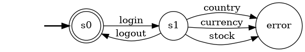

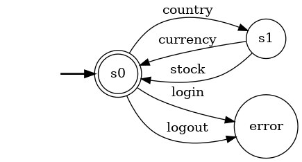

This time, the composition MDP is:

```
mdp = composition_mdp(target, login_service, form_service)
render_composition_mdp(mdp)
```

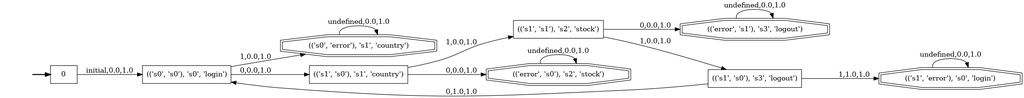

The optimal policy correctly avoids dead ends:

```
opn = DPAnalytic(mdp, 1e-4)
opt_policy = opn.get_optimal_policy_vi()
value_function = opn.get_value_func_dict(opt_policy)
q_value_function = opn.get_act_value_func_dict(opt_policy)

# remove '0' state to sort output
opt_policy.policy_data.pop(0, None)
value_function.pop(0, None)
q_value_function.pop(0, None)

print_policy_data(opt_policy)
print()
print_value_function(value_function)
print()
print_q_value_function(q_value_function)
```

```
Policy:
State=(('error', 's0'), 's2', 'stock'), Action=undefined
State=(('error', 's1'), 's3', 'logout'),    Action=undefined
State=(('s0', 'error'), 's1', 'country'),   Action=undefined
State=(('s0', 's0'), 's0', 'login'),    Action=0
State=(('s1', 'error'), 's0', 'login'), Action=undefined
State=(('s1', 's0'), 's1', 'country'),  Action=1
State=(('s1', 's0'), 's3', 'logout'),   Action=0
State=(('s1', 's1'), 's2', 'stock'),    Action=1

Value function:
State=(('error', 's0'), 's2', 'stock'), value=0.0
State=(('error', 's1'), 's3', 'logout'),    value=0.0
State=(('s0', 'error'), 's1', 'country'),   value=0.0
State=(('s0', 's0'), 's0', 'login'),    value=2.119802268101193
State=(('s1', 'error'), 's0', 'login'), value=0.0
State=(('s1', 's0'), 's1', 'country'),  value=2.3553358534457702
State=(('s1', 's0'), 's3', 'logout'),   value=2.907822041291074
State=(('s1', 's1'), 's2', 'stock'),    value=2.6170398371619665

Q-value function:
State=(('error', 's0'), 's2', 'stock'):
    Action=undefined,   Value=0.0

State=(('error', 's1'), 's3', 'logout'):
    Action=undefined,   Value=0.0

State=(('s0', 'error'), 's1', 'country'):
    Action=undefined,   Value=0.0

State=(('s0', 's0'), 's0', 'login'):
    Action=0,   Value=2.119802268101193
    Action=1,   Value=0.0

State=(('s1', 'error'), 's0', 'login'):
    Action=undefined,   Value=0.0

State=(('s1', 's0'), 's1', 'country'):
    Action=0,   Value=0.0
    Action=1,   Value=2.35533585344577

State=(('s1', 's0'), 's3', 'logout'):
    Action=0,   Value=2.907822041291074
    Action=1,   Value=1.0

State=(('s1', 's1'), 's2', 'stock'):
    Action=0,   Value=0.0
    Action=1,   Value=2.6170398371619665
```

## The Garden Bots System (Yadav & Sardina 2011, AAMAS)

Here we consider a variant of the example described in:

[Yadav, N., & Sardina, S. (2011, May). Decision theoretic behavior composition. In The 10th International Conference on Autonomous Agents and Multiagent Systems -Volume 2 (pp. 575-582).](https://www.researchgate.net/publication/221456691_Decision_theoretic_behavior_composition)

[figure not shown]

> :warning: **NOTE: in the following, for simplicity, we don't consider** - *the environment* and - **the *stochasticity of the services*.**

In the gardening scenario, we assume there are three available garden bots:

- The cleaner bot **BCleaner** cleans the garden by collecting the fallen leaves, dirt, waste, etc., into its own bucket. Its bucket gets filled up with a cleaning session, and the bot has to empty it to be able to start cleaning again. We assume the empty action involves emptying all garden bins as well as the bots' buckets.
- The plucker bot **BPlucker** can pluck and clean the garden; since it is not equipped with a bucket, it plucks and collects from the ground directly.
- the multi-bot **BMulti** has the capability to water the plants and pluck. It has a small bucket, and so it needs to empty it after every plucking session.

The desired behavior required to maintain thegarden in a particular season is not directly represented by any ofthe existing bots in the garden, and is modeled by the deterministic uniform-reward target bot **TGarden** shown in Figure 1. Intuitively, the garden should always be cleaned first to remove any fallen leaves and dirt, followed by either plucking or watering the garden. Since flowers and fruits do not grow everyday, the plucking is required only 30% of the time; 70% of the time a request for watering the garden will be issued. Finally, the bins are to be emptied, and the whole process can repeat again. All requests are of equal value, namely, 1 unit (second component in each transition label).

```
print("BCleaner")
bcleaner_service = build_service_from_transitions(
    {
        "a0": {"clean": "a1"},
        "a1": {"empty": "a0"}
    },
    "a0",
    {"a0"}
)
render_service(bcleaner_service)
```

```
BCleaner
```

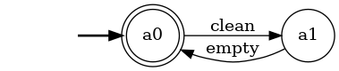

```
print("BMulti")
bmulti_service = build_service_from_transitions(
    {
        "b0": {"water": "b0", "pluck": "b1"},
        "b1": {"water": "b1", "empty": "b0"}
    },
    "b0",
    {"b0"}
)
render_service(bmulti_service)
```

```
BMulti
```

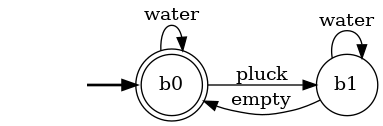

```
print("BPlucker")
bplucker_service = build_service_from_transitions(
    {
        "c0": {"pluck": "c1"},
        "c1": {"clean": "c0"}
    },
    "c0",
    {"c0"}
)
render_service(bplucker_service)
```

```
BPlucker
```

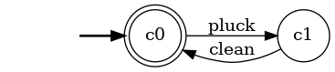

```
target = build_target_from_transitions(
    {
        "t0": {"clean": ("t1", 1.0, 1.0)},
        "t1": {"water": ("t2", 0.7, 1.0), "pluck": ("t3", 0.3, 1.0)},
        "t2": {"empty": ("t0", 1.0, 1.0)},
        "t3": {"empty": ("t0", 1.0, 1.0)},
    },
    "t0",
    {"t0"}
)
render_target(target)
```

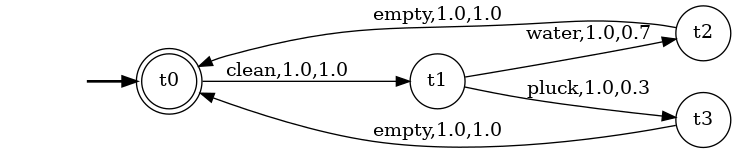

```
mdp = composition_mdp(target, bcleaner_service, bmulti_service, bplucker_service, gamma=0.9)
render_composition_mdp(mdp)
```

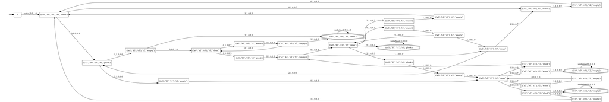

```
opn = DPAnalytic(mdp, 1e-4)
opt_policy = opn.get_optimal_policy_vi()
value_function = opn.get_value_func_dict(opt_policy)
q_value_function = opn.get_act_value_func_dict(opt_policy)

# remove '0' state to sort output
opt_policy.policy_data.pop(0, None)
value_function.pop(0, None)
_ = q_value_function.pop(0, None)
```

```
print_policy_data(opt_policy)
```

```
Policy:
State=(('a0', 'b0', 'c0'), 't0', 'clean'),  Action=0
State=(('a0', 'b0', 'c0'), 't1', 'pluck'),  Action=1
State=(('a0', 'b0', 'c0'), 't1', 'water'),  Action=1
State=(('a0', 'b0', 'c0'), 't2', 'empty'),  Action=undefined
State=(('a0', 'b0', 'c1'), 't0', 'clean'),  Action=0
State=(('a0', 'b0', 'c1'), 't3', 'empty'),  Action=undefined
State=(('a0', 'b1', 'c0'), 't0', 'clean'),  Action=0
State=(('a0', 'b1', 'c0'), 't1', 'pluck'),  Action=2
State=(('a0', 'b1', 'c0'), 't1', 'water'),  Action=1
State=(('a0', 'b1', 'c0'), 't2', 'empty'),  Action=1
State=(('a0', 'b1', 'c0'), 't3', 'empty'),  Action=1
State=(('a0', 'b1', 'c1'), 't0', 'clean'),  Action=2
State=(('a0', 'b1', 'c1'), 't3', 'empty'),  Action=1
State=(('a1', 'b0', 'c0'), 't0', 'clean'),  Action=undefined
State=(('a1', 'b0', 'c0'), 't1', 'pluck'),  Action=1
State=(('a1', 'b0', 'c0'), 't1', 'water'),  Action=1
State=(('a1', 'b0', 'c0'), 't2', 'empty'),  Action=0
State=(('a1', 'b0', 'c1'), 't0', 'clean'),  Action=2
State=(('a1', 'b0', 'c1'), 't1', 'pluck'),  Action=1
State=(('a1', 'b0', 'c1'), 't1', 'water'),  Action=1
State=(('a1', 'b0', 'c1'), 't2', 'empty'),  Action=0
State=(('a1', 'b0', 'c1'), 't3', 'empty'),  Action=0
State=(('a1', 'b1', 'c0'), 't1', 'pluck'),  Action=2
State=(('a1', 'b1', 'c0'), 't1', 'water'),  Action=1
State=(('a1', 'b1', 'c0'), 't2', 'empty'),  Action=0
State=(('a1', 'b1', 'c0'), 't3', 'empty'),  Action=0
State=(('a1', 'b1', 'c1'), 't1', 'pluck'),  Action=undefined
State=(('a1', 'b1', 'c1'), 't1', 'water'),  Action=1
State=(('a1', 'b1', 'c1'), 't2', 'empty'),  Action=0
State=(('a1', 'b1', 'c1'), 't3', 'empty'),  Action=0
```

```
print_value_function(value_function)
```

```
Value function:
State=(('a0', 'b0', 'c0'), 't0', 'clean'),  value=10.000000000000005
State=(('a0', 'b0', 'c0'), 't1', 'pluck'),  value=10.000000000000005
State=(('a0', 'b0', 'c0'), 't1', 'water'),  value=1.0
State=(('a0', 'b0', 'c0'), 't2', 'empty'),  value=0.0
State=(('a0', 'b0', 'c1'), 't0', 'clean'),  value=10.000000000000005
State=(('a0', 'b0', 'c1'), 't3', 'empty'),  value=0.0
State=(('a0', 'b1', 'c0'), 't0', 'clean'),  value=10.000000000000004
State=(('a0', 'b1', 'c0'), 't1', 'pluck'),  value=10.000000000000005
State=(('a0', 'b1', 'c0'), 't1', 'water'),  value=10.000000000000005
State=(('a0', 'b1', 'c0'), 't2', 'empty'),  value=10.000000000000004
State=(('a0', 'b1', 'c0'), 't3', 'empty'),  value=10.000000000000004
State=(('a0', 'b1', 'c1'), 't0', 'clean'),  value=10.000000000000004
State=(('a0', 'b1', 'c1'), 't3', 'empty'),  value=10.000000000000005
State=(('a1', 'b0', 'c0'), 't0', 'clean'),  value=0.0
State=(('a1', 'b0', 'c0'), 't1', 'pluck'),  value=10.000000000000005
State=(('a1', 'b0', 'c0'), 't1', 'water'),  value=10.000000000000005
State=(('a1', 'b0', 'c0'), 't2', 'empty'),  value=10.000000000000004
State=(('a1', 'b0', 'c1'), 't0', 'clean'),  value=10.000000000000005
State=(('a1', 'b0', 'c1'), 't1', 'pluck'),  value=10.000000000000004
State=(('a1', 'b0', 'c1'), 't1', 'water'),  value=10.000000000000005
State=(('a1', 'b0', 'c1'), 't2', 'empty'),  value=10.000000000000005
State=(('a1', 'b0', 'c1'), 't3', 'empty'),  value=10.000000000000005
State=(('a1', 'b1', 'c0'), 't1', 'pluck'),  value=10.000000000000004
State=(('a1', 'b1', 'c0'), 't1', 'water'),  value=10.000000000000004
State=(('a1', 'b1', 'c0'), 't2', 'empty'),  value=10.000000000000004
State=(('a1', 'b1', 'c0'), 't3', 'empty'),  value=10.000000000000005
State=(('a1', 'b1', 'c1'), 't1', 'pluck'),  value=0.0
State=(('a1', 'b1', 'c1'), 't1', 'water'),  value=10.000000000000004
State=(('a1', 'b1', 'c1'), 't2', 'empty'),  value=10.000000000000004
State=(('a1', 'b1', 'c1'), 't3', 'empty'),  value=10.000000000000004
```

```
print_q_value_function(q_value_function)
```

```
Q-value function:
State=(('a0', 'b0', 'c0'), 't0', 'clean'):
    Action=0,   Value=10.000000000000005

State=(('a0', 'b0', 'c0'), 't1', 'pluck'):
    Action=1,   Value=10.000000000000004
    Action=2,   Value=1.0

State=(('a0', 'b0', 'c0'), 't1', 'water'):
    Action=1,   Value=1.0

State=(('a0', 'b0', 'c0'), 't2', 'empty'):
    Action=undefined,   Value=0.0

State=(('a0', 'b0', 'c1'), 't0', 'clean'):
    Action=0,   Value=10.000000000000004
    Action=2,   Value=4.330000000000001

State=(('a0', 'b0', 'c1'), 't3', 'empty'):
    Action=undefined,   Value=0.0

State=(('a0', 'b1', 'c0'), 't0', 'clean'):
    Action=0,   Value=10.000000000000004

State=(('a0', 'b1', 'c0'), 't1', 'pluck'):
    Action=2,   Value=10.000000000000005

State=(('a0', 'b1', 'c0'), 't1', 'water'):
    Action=1,   Value=10.000000000000004

State=(('a0', 'b1', 'c0'), 't2', 'empty'):
    Action=1,   Value=10.000000000000005

State=(('a0', 'b1', 'c0'), 't3', 'empty'):
    Action=1,   Value=10.000000000000005

State=(('a0', 'b1', 'c1'), 't0', 'clean'):
    Action=0,   Value=7.300000000000002
    Action=2,   Value=10.000000000000005

```

[output cut: 43 more lines]

```
    Action=1,   Value=1.0

State=(('a1', 'b1', 'c1'), 't1', 'pluck'):
    Action=undefined,   Value=0.0

State=(('a1', 'b1', 'c1'), 't1', 'water'):
    Action=1,   Value=10.000000000000004

State=(('a1', 'b1', 'c1'), 't2', 'empty'):
    Action=0,   Value=10.000000000000004
    Action=1,   Value=10.000000000000005

State=(('a1', 'b1', 'c1'), 't3', 'empty'):
    Action=0,   Value=10.000000000000004
    Action=1,   Value=10.000000000000005
```

We start from system state `(a0, b0, c0)` and target state `t0`.

- the `clean` action is assigned to `bcleaner` (action `0`). The target takes the transition `t0->t1`, and the system takes the transition `(a0, b0, c0) -> (a1, b0, c0)`.
- Now two things can happen: `water` with probability `0.7` and `pluck` with probability `0.3`.
- with probability `0.7`, the system needs `water`. The `water` action is assigned to `bmulti` (action `1`). The target takes the transition `t1->t2`, and the system takes the transition `(a1, b0, c0) -> (a1, b0, c0)` (same state).
  - Then, the target requests `empty`, which can only be processed by `bcleaner`. The new target state is `t0` and the new system state is `(a0, b0, c0)`, the initial state.
- with probability `0.3`, the system needs `pluck`. This evolution of the system is a bit more convoluted, but the orchestrator is always able to avoid dead-ends.

## Human-Robot Collaboration (HRC) use case

We use the case study described in:

[Tsarouchi, P., Makris, S., & Chryssolouris, G. (2016). On a human and dual-arm robot task planning method. Procedia CIRP, 57, 551-555.](https://www.sciencedirect.com/science/article/pii/S2212827116312495)

Another useful reference: [Wang, L., Liu, S., Liu, H., & Wang, X. V. (2020). Overview of Human-Robot Collaboration in Manufacturing. In Proceedings of 5th International Conference on the Industry 4.0 Model for Advanced Manufacturing (pp. 15-58). Springer, Cham.](https://link.springer.com/chapter/10.1007/978-3-030-46212-3_2)

Consider a hybrid assembly cell for the assembly of a vehicle dashboard in the automotive industry. The cell consists of a **dual arm robot** and a **human**. For this work, some tasks can be carried out by a human and some others by the dual arm robot.

[figure not shown]

The loading and assembly area are used for the picking up and the placement of the traverse (weight $\approx 12 kg$). The fuse box is the next part to be assembled in its final position, in the traverse slot, with the help of three screws for stability reasons. The cable apck is the last part to be installed and is quite flexible. This work is a typical case for combined HR cooperation.

The work load includes four processes: 1. the placement of travers 2. the placement of the computer body 3. the cable pack preparation 4. the installation

[figure not shown]

These processes comprise a number of tasks and a number of suitable resources per task. The suitability of the resources for a task is decided taking into account the weight of the parts compared to the payload capabilities of the resources. Additionally, the flexibility of the parts is taken into account compared to the resource handling capabilities.

[figure not shown]

```
print("arm12")
arm12_service = build_service_from_transitions(
    {
        "s0": {
            "pick_up_traverse": "s0",
            "place_traverse": "s0",
            "pick_up_fuse_box": "s0",
            "place_fuse_box": "s0",
            "pick_up_cable": "s0",
            "approach_table": "s0",
        },
    },
    "s0",
    {"s0"}
)
render_service(arm12_service)
```

```
arm12
```

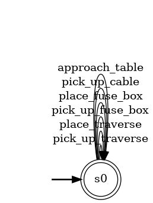

```
print("human")
human_service = build_service_from_transitions(
    {
        "s0": {
            "pick_up_traverse": "s0",
            "place_traverse": "s0",
            "pick_up_fuse_box": "s0",
            "place_fuse_box": "s0",
            "pick_up_cable": "s0",
            "approach_table": "s0",
            "install_pins": "s0",
        },
    },
    "s0",
    {"s0"}
)
render_service(human_service)
```

```
human
```

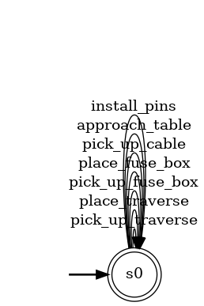

```
print("arm2")
arm2_service = build_service_from_transitions(
    {
        "s0": {
            "pick_up_screw_driver": "s0",
            "pick_up_screw": "s0",
            "install_screw": "s0",
            "place_screw_driver": "s0",
        },
    },
    "s0",
    {"s0"}
)
render_service(arm2_service)
```

```
arm2
```

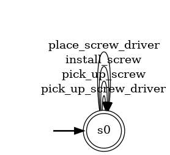

```
target = build_target_from_transitions(
    {
        "t0": {"pick_up_traverse": ("t1", 1.0, 0.0)},
        "t1": {"place_traverse": ("t2", 1.0, 0.0)},
        "t2": {"pick_up_fuse_box": ("t3", 1.0, 0.0)},
        "t3": {"place_fuse_box": ("t4", 1.0, 0.0)},
        "t4": {"pick_up_screw_driver": ("t5", 1.0, 0.0)},
        "t5": {"pick_up_screw": ("t6", 1.0, 0.0)},
        "t6": {"install_screw": ("t7", 1.0, 0.0)},
        "t7": {"place_screw_driver": ("t8", 1.0, 0.0)},
        "t8": {"pick_up_cable": ("t9", 1.0, 0.0)},
        "t9": {"approach_table": ("t10", 1.0, 0.0)},
        "t10": {"install_pins": ("t0", 1.0, 1.0)},
    },
    "t0",
    {"t0"}
)
render_target(target)
```

[figure not shown]

```
mdp = composition_mdp(target, arm12_service, human_service, arm2_service, gamma=0.9)
render_composition_mdp(mdp)
```

[figure not shown]

```
opn = DPAnalytic(mdp, 1e-4)
opt_policy = opn.get_optimal_policy_vi()
value_function = opn.get_value_func_dict(opt_policy)
q_value_function = opn.get_act_value_func_dict(opt_policy)

# remove '0' state to sort output
opt_policy.policy_data.pop(0, None)
value_function.pop(0, None)
q_value_function.pop(0, None)

print_policy_data(opt_policy)
print()
print_value_function(value_function)
print()
print_q_value_function(q_value_function)
```

```
Policy:
State=(('s0', 's0', 's0'), 't0', 'pick_up_traverse'),   Action=0
State=(('s0', 's0', 's0'), 't1', 'place_traverse'), Action=0
State=(('s0', 's0', 's0'), 't10', 'install_pins'),  Action=1
State=(('s0', 's0', 's0'), 't2', 'pick_up_fuse_box'),   Action=0
State=(('s0', 's0', 's0'), 't3', 'place_fuse_box'), Action=0
State=(('s0', 's0', 's0'), 't4', 'pick_up_screw_driver'),   Action=2
State=(('s0', 's0', 's0'), 't5', 'pick_up_screw'),  Action=2
State=(('s0', 's0', 's0'), 't6', 'install_screw'),  Action=2
State=(('s0', 's0', 's0'), 't7', 'place_screw_driver'), Action=2
State=(('s0', 's0', 's0'), 't8', 'pick_up_cable'),  Action=0
State=(('s0', 's0', 's0'), 't9', 'approach_table'), Action=0

Value function:
State=(('s0', 's0', 's0'), 't0', 'pick_up_traverse'),   value=0.5081373132741243
State=(('s0', 's0', 's0'), 't1', 'place_traverse'), value=0.5645970147490269
State=(('s0', 's0', 's0'), 't10', 'install_pins'),  value=1.4573235819467119
State=(('s0', 's0', 's0'), 't2', 'pick_up_fuse_box'),   value=0.6273300163878076
State=(('s0', 's0', 's0'), 't3', 'place_fuse_box'), value=0.6970333515420085
State=(('s0', 's0', 's0'), 't4', 'pick_up_screw_driver'),   value=0.7744815017133427
State=(('s0', 's0', 's0'), 't5', 'pick_up_screw'),  value=0.860535001903714
State=(('s0', 's0', 's0'), 't6', 'install_screw'),  value=0.9561500021152377
State=(('s0', 's0', 's0'), 't7', 'place_screw_driver'), value=1.062388891239153
State=(('s0', 's0', 's0'), 't8', 'pick_up_cable'),  value=1.1804321013768366
State=(('s0', 's0', 's0'), 't9', 'approach_table'), value=1.3115912237520406

Q-value function:
State=(('s0', 's0', 's0'), 't0', 'pick_up_traverse'):
    Action=0,   Value=0.5081373132741243
    Action=1,   Value=0.5081373132741243

State=(('s0', 's0', 's0'), 't1', 'place_traverse'):
    Action=0,   Value=0.5645970147490269
    Action=1,   Value=0.5645970147490269

State=(('s0', 's0', 's0'), 't10', 'install_pins'):
    Action=1,   Value=1.4573235819467119

State=(('s0', 's0', 's0'), 't2', 'pick_up_fuse_box'):
    Action=0,   Value=0.6273300163878077
```

[output cut: 10 more lines]

```
    Action=2,   Value=0.8605350019037139

State=(('s0', 's0', 's0'), 't6', 'install_screw'):
    Action=2,   Value=0.9561500021152377

State=(('s0', 's0', 's0'), 't7', 'place_screw_driver'):
    Action=2,   Value=1.062388891239153

State=(('s0', 's0', 's0'), 't8', 'pick_up_cable'):
    Action=0,   Value=1.1804321013768366
    Action=1,   Value=1.1804321013768366

State=(('s0', 's0', 's0'), 't9', 'approach_table'):
    Action=0,   Value=1.3115912237520406
    Action=1,   Value=1.3115912237520406
```

## Media room scenario (Yadav et al. 2013, IJCAI)

This use case is inspired by:

[Yadav, N., Felli, P., De Giacomo, G., & Sardina, S. (2013, August). Supremal Realizability of Behaviors with Uncontrollable Exogenous Events. In IJCAI (pp. 1176-1182).](http://www.diag.uniroma1.it/~degiacom/papers/2013/IJCAI13yfds-long.pdf)

[figure not shown]

The services of this scenario are:

```
print("projector service")
projector_service = build_service_from_transitions(
    {
        "p0": {
            "warm_up": "p1",
            "source": "p2",
        },
        "p1": {
            "source": "p3",
            "fuse": "p5",
        },
        "p2": {
            "warm_up": "p3",
            "error": "p4",
        },
        "p3": {
            "off": "p0",
            "fuse": "p5",
        },
        "p4": {
            "reset": "p0",
        },
        "p5": {
            "repair": "p0",
        },
    },
    "p0",
    {"p0"}
)
render_service(projector_service)
```

```
projector service
```

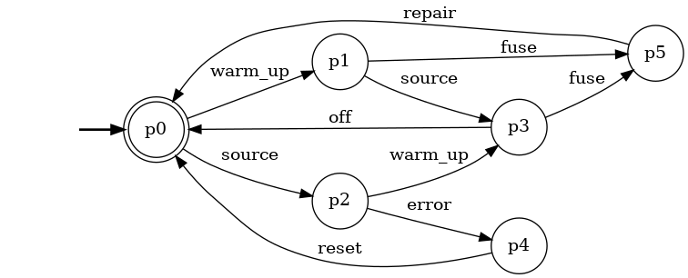

```
print("audio service")
audio_service = build_service_from_transitions(
    {
        "a0": {
            "spk_on": "a1",
        },
        "a1": {
            "spk_off": "a0",
        },
    },
    "a0",
    {"a0"}
)
render_service(audio_service)
```

```
audio service
```

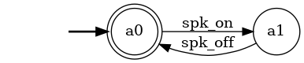

```
target = build_target_from_transitions(
    {
        "t0": {"spk_on": ("t1", 1.0, 0.0)},
        "t1": {"warm_up": ("t2", 0.5, 0.0),
               "source": ("t3", 0.5, 0.0)},
        "t2": {"source": ("t4", 0.9, 0.0),
               "fuse": ("t6", 0.1, -1.0)},
        "t3": {"warm_up": ("t4", 1.0, 0.0)},
        "t4": {"spk_off": ("t5", 0.9, 0.0),
               "fuse": ("t6", 0.1, -1.0)},
        "t5": {"off": ("t0", 1.0, 1.0)},
        "t6": {"repair": ("t1", 1.0, 0.0)},
    },
    "t0",
    {"t0"}
)
render_target(target)
```

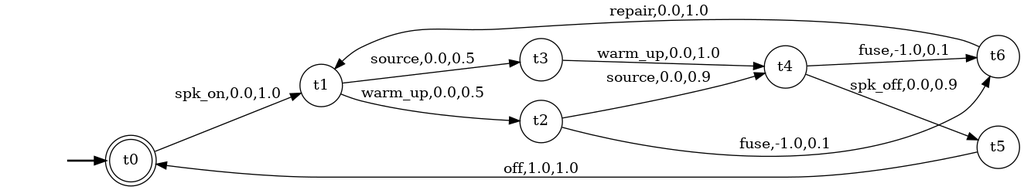

```
mdp = composition_mdp(target, projector_service, audio_service, gamma=0.9)
render_composition_mdp(mdp)
```

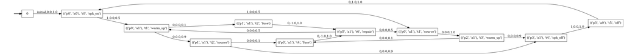

```
opn = DPAnalytic(mdp, 1e-4)
opt_policy = opn.get_optimal_policy_vi()
value_function = opn.get_value_func_dict(opt_policy)
q_value_function = opn.get_act_value_func_dict(opt_policy)

# remove '0' state to sort output
opt_policy.policy_data.pop(0, None)
value_function.pop(0, None)
q_value_function.pop(0, None)

print_policy_data(opt_policy)
print()
print_value_function(value_function)
print()
print_q_value_function(q_value_function)
```

```
Policy:
State=(('p0', 'a0'), 't0', 'spk_on'),   Action=1
State=(('p0', 'a1'), 't1', 'source'),   Action=0
State=(('p0', 'a1'), 't1', 'warm_up'),  Action=0
State=(('p1', 'a1'), 't2', 'fuse'), Action=0
State=(('p1', 'a1'), 't2', 'source'),   Action=0
State=(('p2', 'a1'), 't3', 'warm_up'),  Action=0
State=(('p3', 'a0'), 't5', 'off'),  Action=0
State=(('p3', 'a1'), 't4', 'fuse'), Action=0
State=(('p3', 'a1'), 't4', 'spk_off'),  Action=1
State=(('p5', 'a1'), 't6', 'repair'),   Action=0

Value function:
State=(('p0', 'a0'), 't0', 'spk_on'),   value=1.1384098283455693
State=(('p0', 'a1'), 't1', 'source'),   value=1.3303096960261673
State=(('p0', 'a1'), 't1', 'warm_up'),  value=1.199489922519542
State=(('p1', 'a1'), 't2', 'fuse'), value=0.02456884551101224
State=(('p1', 'a1'), 't2', 'source'),   value=1.4781218844735193
State=(('p2', 'a1'), 't3', 'warm_up'),  value=1.4781218844735193
State=(('p3', 'a0'), 't5', 'off'),  value=2.0245688455110127
State=(('p3', 'a1'), 't4', 'fuse'), value=0.024568845511012252
State=(('p3', 'a1'), 't4', 'spk_off'),  value=1.8221119609599112
State=(('p5', 'a1'), 't6', 'repair'),   value=1.1384098283455693

Q-value function:
State=(('p0', 'a0'), 't0', 'spk_on'):
    Action=1,   Value=1.1384098283455693

State=(('p0', 'a1'), 't1', 'source'):
    Action=0,   Value=1.3303096960261673

State=(('p0', 'a1'), 't1', 'warm_up'):
    Action=0,   Value=1.1994899225195417

State=(('p1', 'a1'), 't2', 'fuse'):
    Action=0,   Value=0.02456884551101246

State=(('p1', 'a1'), 't2', 'source'):
    Action=0,   Value=1.4781218844735193

State=(('p2', 'a1'), 't3', 'warm_up'):
    Action=0,   Value=1.4781218844735193

State=(('p3', 'a0'), 't5', 'off'):
    Action=0,   Value=2.0245688455110127

State=(('p3', 'a1'), 't4', 'fuse'):
    Action=0,   Value=0.02456884551101246

State=(('p3', 'a1'), 't4', 'spk_off'):
    Action=1,   Value=1.8221119609599115

State=(('p5', 'a1'), 't6', 'repair'):
    Action=0,   Value=1.1384098283455693
```